# Metro Interstate Traffic Volumen

# 14.1 Candidate models comparation

```r
candidate_models <- list("Full model"= model_1_full, "Stepwise model"= model_2_step, "Full model (Log)"= model_3_full_log, "Stepwise model (Log)"= model_4_step_log)

selectionTable <- aictab(cand.set = candidate_models)
print(paste0("***********            Full Models              ***********"))
```

```
## [1] "***********            Full Models              ***********"
```

```r
selectionTable
```

```
##
## Model selection based on AICc:
##
##                       K     AICc Delta_AICc AICcWt Cum.Wt         LL
## Stepwise model (Log) 10 107934.6       0.00   0.71   0.71  -53957.32
## Full model (Log)     11 107936.5       1.83   0.29   1.00  -53957.23
## Full model           11 861342.2  753407.51   0.00   1.00 -430660.07
## Stepwise model        9 861387.3  753452.62   0.00   1.00 -430684.63
```

```r
print(paste0("-----------------------------------------------------------"))
```

```
## [1] "-----------------------------------------------------------"
```

```r
print(paste0("***********           Training Models           ***********"))
```

```
## [1] "***********           Training Models           ***********"
```

```r
selection_Training_models
```

```
##
## Model selection based on AICc:
##
##                          K     AICc Delta_AICc AICcWt Cum.Wt        LL
## Stepwise training model 10 81472.01       0.00   0.61   0.61 -40726.00
## Training model          11 81472.92       0.91   0.39   1.00 -40725.45
```

# 14.2 Selecting the best fitting model

The best fitting model was “Stepwise training model” which has the next formula:

formula = traffic_volume ~ temp + rain_1h + clouds_all + time + holiday + moderately_bad_weather + moderately_good_weather + good_weather

```r
#The best model from Full data set
summary(model_4_step_log)
```

```
##
## Call:
## lm(formula = traffic_volume ~ temp + rain_1h + clouds_all + time +
##     holiday + moderately_bad_weather + moderately_good_weather +
##     good_weather, data = metro_Log)
##
## Residuals:
##     Min      1Q  Median      3Q     Max
## -8.5332 -0.5170  0.1879  0.5220  2.0014
##
## Coefficients:
##                          Estimate Std. Error t value             Pr(>|t|)
## (Intercept)             -1.461482   0.432032  -3.383             0.000718 ***
## temp                     1.305807   0.076325  17.109 < 0.0000000000000002 ***
## rain_1h                 -0.089150   0.013757  -6.480    0.000000000092308 ***
## clouds_all               0.027126   0.003754   7.225    0.000000000000508 ***
## time                     0.758602   0.004245 178.724 < 0.0000000000000002 ***
## holiday                  0.697621   0.095461   7.308    0.000000000000276 ***
## moderately_bad_weather   0.026942   0.010804   2.494             0.012644 *
## moderately_good_weather  0.086547   0.010029   8.630 < 0.0000000000000002 ***
## good_weather             0.060394   0.016136   3.743             0.000182 ***
## ---
## Signif. codes:  0 '***' 0.001 '**' 0.01 '*' 0.05 '.' 0.1 ' ' 1
##
## Residual standard error: 0.7414 on 48184 degrees of freedom
## Multiple R-squared:  0.4231, Adjusted R-squared:  0.423
## F-statistic:  4417 on 8 and 48184 DF,  p-value: < 0.00000000000000022
```

```r
best_model_full_dataset <- model_4_step_log
print("************************************************************************")
```

```
## [1] "************************************************************************"
```

```r
#The best model from Training data set
summary(model_train_2_step)
```

```
##
## Call:
## lm(formula = traffic_volume ~ temp + rain_1h + clouds_all + time +
##     holiday + moderately_bad_weather + moderately_good_weather +
##     good_weather, data = metro_log_split_Train)
##
## Residuals:
##     Min      1Q  Median      3Q     Max
## -8.5306 -0.5174  0.1878  0.5231  2.0012
##
## Coefficients:
##                          Estimate Std. Error t value             Pr(>|t|)
## (Intercept)             -1.164475   0.500284  -2.328              0.01994 *
## temp                     1.253830   0.088390  14.185 < 0.0000000000000002 ***
## rain_1h                 -0.082779   0.016023  -5.166  0.00000024008222638 ***
## clouds_all               0.026346   0.004327   6.089  0.00000000114926297 ***
## time                     0.757564   0.004918 154.048 < 0.0000000000000002 ***
## holiday                  0.744272   0.116823   6.371  0.00000000019011716 ***
## moderately_bad_weather   0.030072   0.012484   2.409              0.01601 *
## moderately_good_weather  0.091104   0.011623   7.838  0.00000000000000469 ***
## good_weather             0.055307   0.018602   2.973              0.00295 **
## ---
## Signif. codes:  0 '***' 0.001 '**' 0.01 '*' 0.05 '.' 0.1 ' ' 1
##
## Residual standard error: 0.7443 on 36242 degrees of freedom
## Multiple R-squared:  0.4201, Adjusted R-squared:   0.42
## F-statistic:  3282 on 8 and 36242 DF,  p-value: < 0.00000000000000022
```

```r
best_model_training_dataset <- model_train_2_step
```

# 14.3 Creating a new data frame with the variables of the best fitting model

```r
myvars <- c("traffic_volume", "temp", "rain_1h", "clouds_all", "time", "holiday", "moderately_bad_weather", "moderately_good_weather", "good_weather")

df_best_model <- metro_log_split_df[myvars]
names(df_best_model)
```

```
## [1] "traffic_volume"          "temp"
## [3] "rain_1h"                 "clouds_all"
## [5] "time"                    "holiday"
## [7] "moderately_bad_weather"  "moderately_good_weather"
## [9] "good_weather"
```

## 14.4 Full model with the new data set

```r
set.seed(145)
#backup
df_split_best_model <- df_best_model
train_part1 <-  sample.split(df_split_best_model$traffic_volume, SplitRatio = 0.75)
df_split_train1 <-  subset(df_split_best_model, train_part==TRUE)
df_split_test1 <-  subset(df_split_best_model, train_part==FALSE)

print(paste0("Split the new data set from best model:          ",nrow(df_split_best_model)))
```

```
## [1] "Split the new data set from best model:          48193"
```

```r
print(paste0("Training the new data set from best model (90%): ",nrow(df_split_train1)))
```

[output not shown]

```r
print(paste0("Testing the new data set from best model(10%):   ",nrow(df_split_test1)))
```

[output not shown]

# 14.5 Training the best model

```r
train_best_model <- lm(traffic_volume ~., data = df_split_train1)
options(scipen = 999)
summary(train_best_model)
```

```
##
## Call:
## lm(formula = traffic_volume ~ ., data = df_split_train1)
##
## Residuals:
##     Min      1Q  Median      3Q     Max
## -8.5306 -0.5174  0.1878  0.5231  2.0012
##
## Coefficients:
##                          Estimate Std. Error t value             Pr(>|t|)
## (Intercept)             -1.164475   0.500284  -2.328              0.01994 *
## temp                     1.253830   0.088390  14.185 < 0.0000000000000002 ***
## rain_1h                 -0.082779   0.016023  -5.166  0.00000024008222638 ***
## clouds_all               0.026346   0.004327   6.089  0.00000000114926297 ***
## time                     0.757564   0.004918 154.048 < 0.0000000000000002 ***
## holiday                  0.744272   0.116823   6.371  0.00000000019011716 ***
## moderately_bad_weather   0.030072   0.012484   2.409              0.01601 *
## moderately_good_weather  0.091104   0.011623   7.838  0.00000000000000469 ***
## good_weather             0.055307   0.018602   2.973              0.00295 **
## ---
## Signif. codes:  0 '***' 0.001 '**' 0.01 '*' 0.05 '.' 0.1 ' ' 1
##
## Residual standard error: 0.7443 on 36242 degrees of freedom
## Multiple R-squared:  0.4201, Adjusted R-squared:   0.42
## F-statistic:  3282 on 8 and 36242 DF,  p-value: < 0.00000000000000022
```

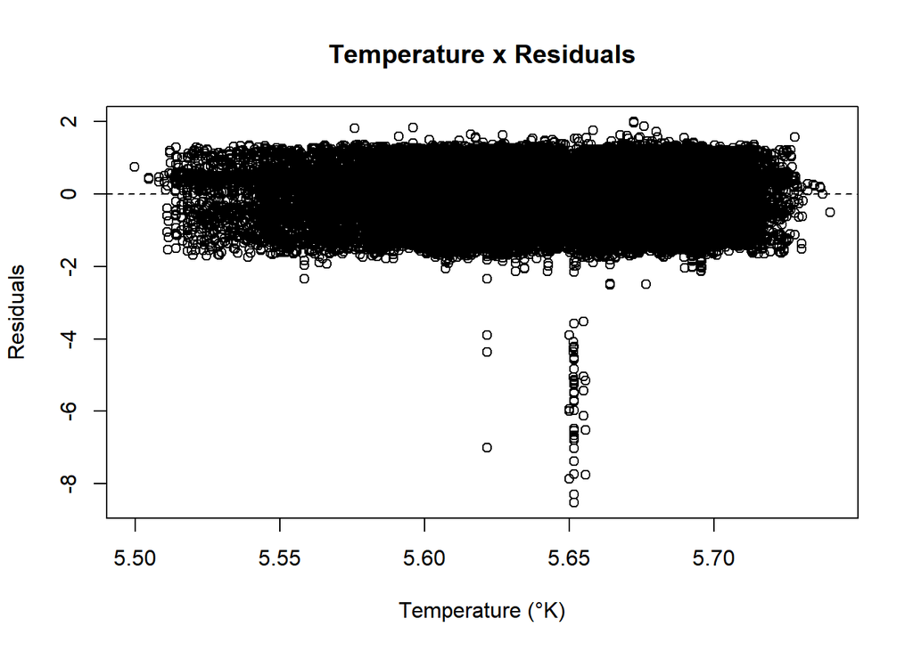

```r
#Temperature x Residuals Plot
plot(train_best_model$residuals~df_split_train1$temp[order(df_split_train1$temp)],
 main="Temperature x Residuals",
 xlab="Temperature (°K)", ylab="Residuals")
abline(h=0,lty=2)
```

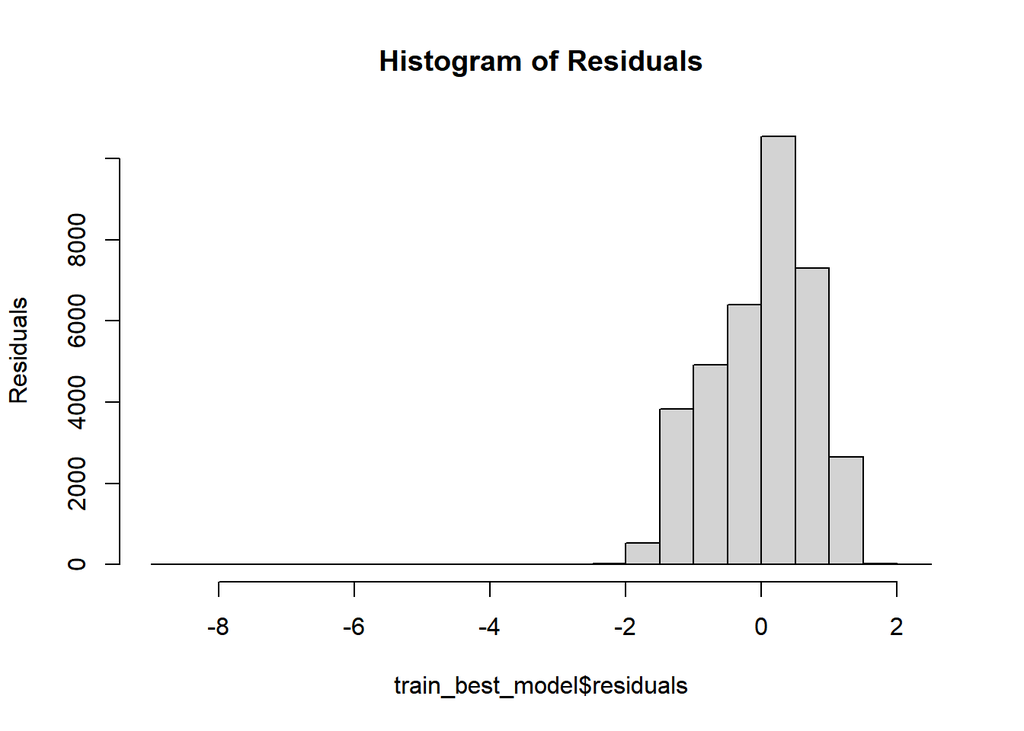

```r
#Histogram of Residuals
hist(train_best_model$residuals, main="Histogram of Residuals",
 ylab="Residuals")
```

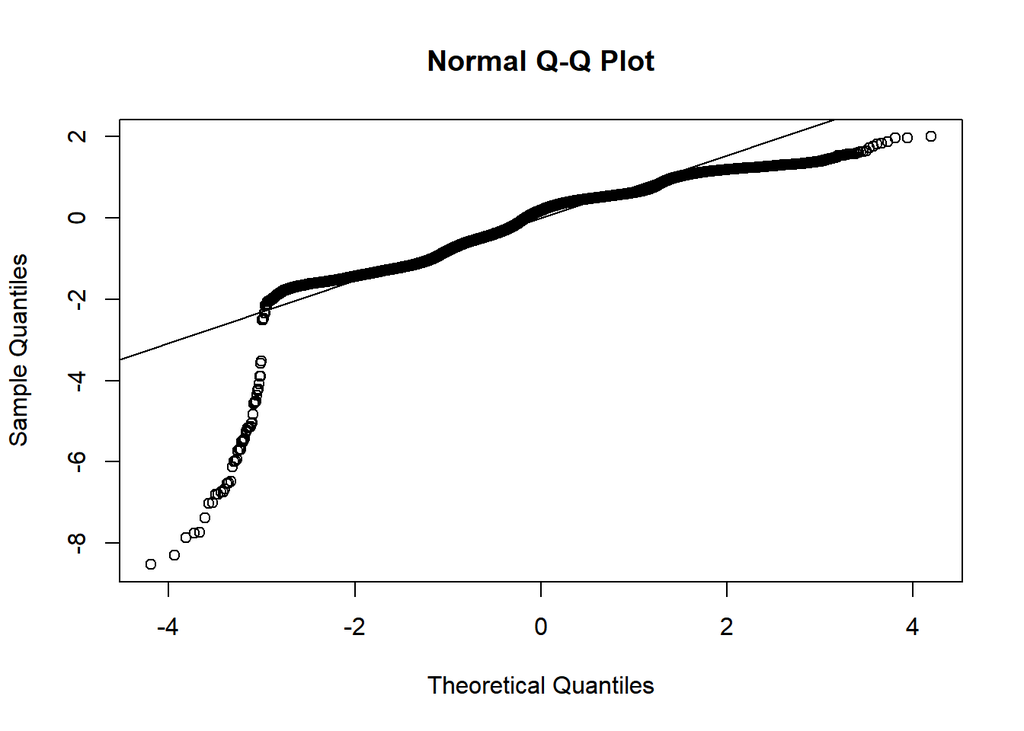

```r
#Q-Q Plot
qqnorm(train_best_model$residuals)
qqline(train_best_model$residuals)
```

# STEP 15 DISPLAYING PREDICTED, ACTUAL, AND RESIDUALS VALUES.

```r
library(forecast)
#Prediction of the best model
best_model_training_dataset_pred <- predict(train_best_model, df_split_train1)

#Training Model

print("-------------Validation Model---------------------")
```

```
## [1] "-------------Validation Model---------------------"
```

```r
print("-------------  Best Model    ---------------------")
```

```
## [1] "-------------  Best Model    ---------------------"
```

```r
accuracy(best_model_training_dataset_pred, df_split_train1$traffic_volume)
```

```
##                              ME      RMSE       MAE  MPE MAPE
## Test set -0.0000000000000926192 0.7441642 0.6132536 -Inf  Inf
```

# 15.1 Display the dataframe of predicted values

```r
pred_values <- data.frame("Predicted" = best_model_training_dataset_pred[1:50],
                          "Actual" = df_split_train1$traffic_volume[1:50],
                          "Residual" = best_model_training_dataset_pred[1:50] - df_split_train1$traffic_volume[1:50])
pred_values
```

```
##    Predicted   Actual    Residual
## 1   7.874774 8.620832 -0.74605823
## 2   7.967909 8.415603 -0.44769387
## 3   8.039521 8.469682 -0.43016082
## 4   8.102530 8.522579 -0.42004880
## 5   8.158268 8.500861 -0.34259234
## 6   8.081390 8.552946 -0.47155649
## 8   8.185342 8.702178 -0.51683576
## 9   8.327579 8.664233 -0.33665396
## 10  8.364112 8.470311 -0.10619882
## 12  8.326226 7.932003  0.39422274
## 13  8.358139 7.767264  0.59087462
## 14  8.385520 7.333023  1.05249731
## 15  8.410299 6.871091  1.53920803
## 16  5.999124 6.228511 -0.22938673
```

[output cut: 36 more lines]

## 15.2 Visualilization of predicted and actual values

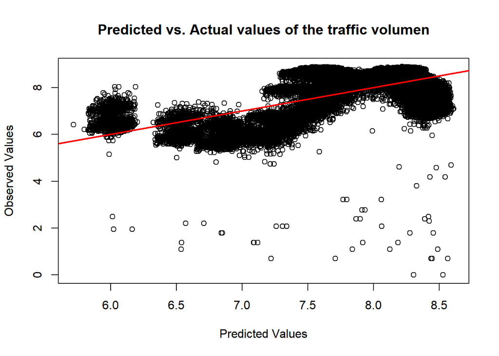

```r
plot(predict(train_best_model),
     df_split_train1$traffic_volume,
     xlab = "Predicted Values",
     ylab = "Observed Values", main = "Predicted vs. Actual values of the traffic volumen")
abline(a = 0,
       b = 1,
       col = "red",
       lwd = 2)
```

# STEP 16 Visualization of predicted values from the best model

```r
#install.packages("jtools", "sjPlot", "sjmisc")
library(jtools)
library(sjPlot)
library(sjmisc)
# Plotting the best model
set_theme(base = theme_bw())

best_model_full_dataset
```

```
##
## Call:
## lm(formula = traffic_volume ~ temp + rain_1h + clouds_all + time +
##     holiday + moderately_bad_weather + moderately_good_weather +
##     good_weather, data = metro_Log)
##
## Coefficients:
##             (Intercept)                     temp                  rain_1h
##                -1.46148                  1.30581                 -0.08915
##              clouds_all                     time                  holiday
##                 0.02713                  0.75860                  0.69762
##  moderately_bad_weather  moderately_good_weather             good_weather
##                 0.02694                  0.08655                  0.06039
```

```r
best_model_training_dataset
```

```
##
## Call:
## lm(formula = traffic_volume ~ temp + rain_1h + clouds_all + time +
##     holiday + moderately_bad_weather + moderately_good_weather +
##     good_weather, data = metro_log_split_Train)
##
## Coefficients:
##             (Intercept)                     temp                  rain_1h
##                -1.16447                  1.25383                 -0.08278
##              clouds_all                     time                  holiday
##                 0.02635                  0.75756                  0.74427
##  moderately_bad_weather  moderately_good_weather             good_weather
##                 0.03007                  0.09110                  0.05531
```

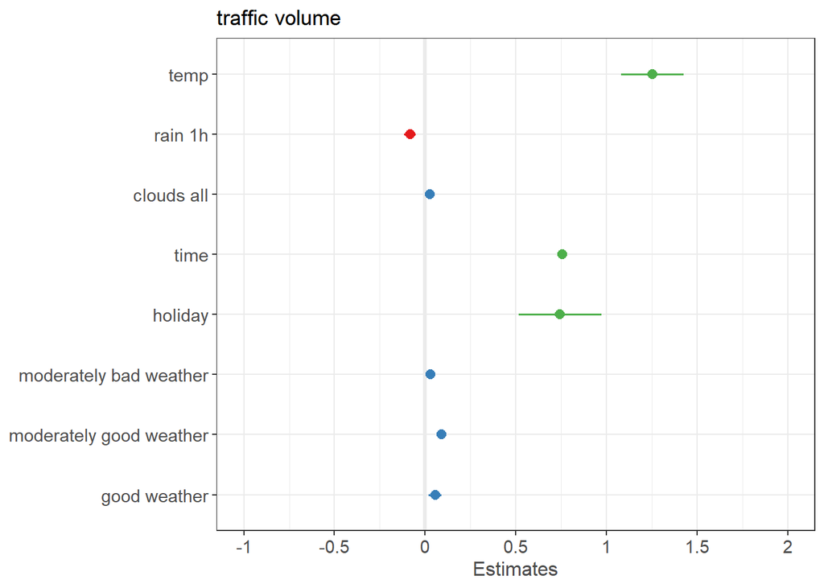

```r
plot_model(best_model_training_dataset, group.terms = c(4,1,2,4,4,2,2,2))
```

## 16.1 Getting predicted values from independent variables

### 16.1.1 Getting predicted values from log transfomated data set

```r
# We got predicted values based on different scenarios
y <- get_model_data(
  train_best_model,
  type = c("pred"),
  colors = "Set1",
  case = "parsed",
  digits = 2
)
y
```

```
## $temp
## # Predicted values of traffic_volume
##
## temp | Predicted | group_col |       95% CI
## -------------------------------------------
## 5.40 |      7.40 |      temp | [7.36, 7.45]
## 5.50 |      7.53 |      temp | [7.50, 7.56]
## 5.60 |      7.65 |      temp | [7.63, 7.68]
## 5.70 |      7.78 |      temp | [7.76, 7.80]
##
## Adjusted for:
## *                 rain_1h = 0.05
## *              clouds_all = 3.05
## *                    time = 2.27
## *                 holiday = 0.00
## *  moderately_bad_weather = 0.00
## * moderately_good_weather = 0.00
## *            good_weather = 0.00
##
## $rain_1h
## # Predicted values of traffic_volume
##
## rain_1h | Predicted | group_col |       95% CI
## ----------------------------------------------
##       0 |      7.71 |   rain_1h | [7.69, 7.73]
##       1 |      7.63 |   rain_1h | [7.60, 7.66]
##       2 |      7.55 |   rain_1h | [7.48, 7.61]
##       3 |      7.46 |   rain_1h | [7.37, 7.55]
##       4 |      7.38 |   rain_1h | [7.26, 7.50]
##       5 |      7.30 |   rain_1h | [7.14, 7.45]
##
## Adjusted for:
## *                    temp = 5.64
## *              clouds_all = 3.05
## *                    time = 2.27
## *                 holiday = 0.00
## *  moderately_bad_weather = 0.00
## * moderately_good_weather = 0.00
## *            good_weather = 0.00
##
```

[output cut: 98 more lines]

```
## # Predicted values of traffic_volume
##
## good_weather | Predicted |    group_col |       95% CI
## ------------------------------------------------------
##            0 |      7.71 | good_weather | [7.69, 7.73]
##            1 |      7.76 | good_weather | [7.74, 7.79]
##
## Adjusted for:
## *                    temp = 5.64
## *                 rain_1h = 0.05
## *              clouds_all = 3.05
## *                    time = 2.27
## *                 holiday = 0.00
## *  moderately_bad_weather = 0.00
## * moderately_good_weather = 0.00
```

### 16.1.2 reversing Log transformated values to real values in order to analysis and make understandeable interpretation of predictions

```r
c <- do.call(rbind.data.frame, y) |> as.data.frame()
real_predicted_values <- exp(c[,1:5])
print(real_predicted_values)
```

```
##                                    x predicted std.error  conf.low conf.high
## temp.1                    221.406416 1641.3190  1.024417 1565.5214 1720.7864
## temp.2                    244.691932 1860.5706  1.016628 1801.3951 1921.6900
## temp.3                    270.426407 2109.1104  1.010932 2064.6396 2154.5391
## temp.4                    298.867401 2390.8508  1.011049 2339.9099 2442.9007
## rain_1h.1                   1.000000 2232.4329  1.010261 2188.2075 2277.5521
## rain_1h.2                   2.718282 2055.0756  1.016662 1989.5813 2122.7258
## rain_1h.3                   7.389056 1891.8085  1.031392 1780.6020 2009.9604
## rain_1h.4                  20.085537 1741.5124  1.047474 1590.1821 1907.2440
## rain_1h.5                  54.598150 1603.1566  1.064104 1419.3463 1810.7711
## rain_1h.6                 148.413159 1475.7926  1.081117 1266.5890 1719.5507
## clouds_all.1                1.000000 2050.8070  1.019893 1973.1399 2131.5312
## clouds_all.2                1.648721 2078.0006  1.017964 2006.7383 2151.7935
## clouds_all.3                2.718282 2105.5549  1.016107 2040.6343 2172.5408
## clouds_all.4                4.481689 2133.4745  1.014351 2074.7165 2193.8966
## clouds_all.5                7.389056 2161.7643  1.012733 2108.8136 2216.0445
## clouds_all.6               12.182494 2190.4292  1.011312 2142.6677 2239.2554
## clouds_all.7               20.085537 2219.4743  1.010166 2175.9080 2263.9128
## clouds_all.8               33.115452 2248.9045  1.009395 2208.0602 2290.5043
## clouds_all.9               54.598150 2278.7249  1.009094 2238.6479 2319.5194
## clouds_all.10              90.017131 2308.9407  1.009308 2267.3933 2351.2494
## clouds_all.11             148.413159 2339.5572  1.010003 2294.3609 2385.6439
## time.1                      1.000000  397.5911  1.014735  386.3544  409.1545
## time.2                      1.221403  462.6343  1.014023  450.1779  475.4353
## time.3                      1.491825  538.3182  1.013348  524.5078  552.4922
## time.4                      1.822119  626.3834  1.012716  611.0607  642.0904
## time.5                      2.225541  728.8556  1.012133  711.8293  746.2890
## time.6                      2.718282  848.0914  1.011606  829.1257  867.4910
## time.7                      3.320117  986.8335  1.011143  965.6312 1008.5014
## time.8                      4.055200 1148.2729  1.010752 1124.4539 1172.5964
## time.9                      4.953032 1336.1226  1.010441 1309.1963 1363.6028
## time.10                     6.049647 1554.7034  1.010218 1524.0334 1585.9905
## time.11                     7.389056 1809.0424  1.010087 1773.8054 1844.9794
## time.12                     9.025013 2104.9896  1.010052 2064.1258 2146.6624
## time.13                    11.023176 2449.3518  1.010115 2401.5092 2498.1476
## time.14                    13.463738 2850.0494  1.010274 2793.5196 2907.7231
## time.15                    16.444647 3316.2984  1.010524 3248.9440 3385.0491
## time.16                    20.085537 3858.8226  1.010859 3777.9921 3941.3825
## time.17                    24.532530 4490.1002  1.011273 4392.5280 4589.8398
## holiday.1                   1.000000 2222.6054  1.010064 2179.4100 2266.6571
## holiday.2                   2.718282 4678.3804  1.124325 3718.3422 5886.2907
## moderately_bad_weather.1    1.000000 2222.6054  1.010064 2179.4100 2266.6571
## moderately_bad_weather.2    2.718282 2290.4589  1.009023 2250.4866 2331.1412
## moderately_good_weather.1   1.000000 2222.6054  1.010064 2179.4100 2266.6571
## moderately_good_weather.2   2.718282 2434.6032  1.008306 2395.4508 2474.3954
## good_weather.1              1.000000 2222.6054  1.010064 2179.4100 2266.6571
## good_weather.2              2.718282 2348.9930  1.012585 2292.1161 2407.2812
```

### Loading table library to reports

```r
#install.packages("flextable")
library(flextable)
```

### 16.1.3 Predicted values to temperature and traffic volume

$temp Adjusted for: rain_1h = 1.051271 clouds_all = 21.115344 time = 9.679401 holiday = 0.00 moderately_bad_weather = 0.00 moderately_good_weather = 0.00 good_weather = 0.00

```r
values <- c(0.05,3.05,2.27)
values <- exp(values)
values
```

```
## [1]  1.051271 21.115344  9.679401
```

```r
temp_df <- real_predicted_values[1:4,]
names(temp_df)[1] <- "Temperature (°K)"

temp_tb <- flextable(head(temp_df))
temp_tb <- temp_tb %>% color(j = "Temperature (°K)", color = "blue", part = "all") %>%
  bold(j = c("Temperature (°K)", "predicted"), bold = TRUE)
temp_tb <- theme_vanilla(temp_tb)
temp_tb
```

| Temperature (°K) | predicted | std.error | conf.low | conf.high |
| --- | --- | --- | --- | --- |
| 221.4064 | 1,641.319 | 1.024417 | 1,565.521 | 1,720.786 |
| 244.6919 | 1,860.571 | 1.016628 | 1,801.395 | 1,921.690 |
| 270.4264 | 2,109.110 | 1.010932 | 2,064.640 | 2,154.539 |
| 298.8674 | 2,390.851 | 1.011049 | 2,339.910 | 2,442.901 |

### 16.1.4 Predicted values to raining 1 hour and traffic volume

```r
values <- c(5.64,3.05,2.27)
values <- exp(values)
#values

rain_1h_df <- real_predicted_values[5:10,]
names(rain_1h_df)[1] <- "rain_1h"

rain_tb <- flextable(head(rain_1h_df))
rain_tb <- rain_tb %>% color(j = "rain_1h", color = "blue", part = "all") %>%
  bold(j = c("rain_1h", "predicted"), bold = TRUE)
rain_tb <- theme_vanilla(rain_tb)
rain_tb
```

| rain_1h | predicted | std.error | conf.low | conf.high |
| --- | --- | --- | --- | --- |
| 1.000000 | 2,232.433 | 1.010261 | 2,188.207 | 2,277.552 |
| 2.718282 | 2,055.076 | 1.016662 | 1,989.581 | 2,122.726 |
| 7.389056 | 1,891.809 | 1.031392 | 1,780.602 | 2,009.960 |
| 20.085537 | 1,741.512 | 1.047474 | 1,590.182 | 1,907.244 |
| 54.598150 | 1,603.157 | 1.064104 | 1,419.346 | 1,810.771 |
| 148.413159 | 1,475.793 | 1.081117 | 1,266.589 | 1,719.551 |

### 16.1.5 Predicted values to the clouds (%) and traffic volume

$Clouds_all Adjusted for: temp = 281.46 rain_1h = 1.051271 time = 9.679 holiday = 0.00 moderately_bad_weather = 0.00 moderately_good_weather = 0.00 good_weather = 0.00

```r
values <- c(5.64,0.05,2.27)
values <- exp(values)
#values

clouds_df <- real_predicted_values[11:21,]
names(clouds_df)[1] <- "Clouds"

clouds_tb <- flextable(head(clouds_df))
clouds_tb <- clouds_tb %>% color(j = "Clouds", color = "blue", part = "all") %>%
  bold(j = c("Clouds", "predicted"), bold = TRUE)
clouds_tb <- theme_vanilla(clouds_tb)
clouds_tb
```

| Clouds | predicted | std.error | conf.low | conf.high |
| --- | --- | --- | --- | --- |
| 1.000000 | 2,050.807 | 1.019893 | 1,973.140 | 2,131.531 |
| 1.648721 | 2,078.001 | 1.017964 | 2,006.738 | 2,151.794 |
| 2.718282 | 2,105.555 | 1.016107 | 2,040.634 | 2,172.541 |
| 4.481689 | 2,133.474 | 1.014351 | 2,074.716 | 2,193.897 |
| 7.389056 | 2,161.764 | 1.012733 | 2,108.814 | 2,216.045 |
| 12.182494 | 2,190.429 | 1.011312 | 2,142.668 | 2,239.255 |

### 16.1.6 Predicted values to the daytime and traffic volume

$time Adjusted for: temp = 281.46 rain_1h = 1.051 clouds_all = 21.115 holiday = 0.00 moderately_bad_weather = 0.00 moderately_good_weather = 0.00 good_weather = 0.00

```r
values <- c(5.64,0.05,3.05)
values <- exp(values)
#values

time_df <- real_predicted_values[22:38,]
names(time_df)[1] <- "Daytime"

daytime_tb <- flextable(head(time_df))
daytime_tb <- daytime_tb %>% color(j = "Daytime", color = "blue", part = "all") %>%
  bold(j = c("Daytime", "predicted"), bold = TRUE)
daytime_tb <- theme_vanilla(daytime_tb)
daytime_tb
```

| Daytime | predicted | std.error | conf.low | conf.high |
| --- | --- | --- | --- | --- |
| 1.000000 | 397.5911 | 1.014735 | 386.3544 | 409.1545 |
| 1.221403 | 462.6343 | 1.014023 | 450.1779 | 475.4353 |
| 1.491825 | 538.3182 | 1.013348 | 524.5078 | 552.4922 |
| 1.822119 | 626.3834 | 1.012716 | 611.0607 | 642.0904 |
| 2.225541 | 728.8556 | 1.012133 | 711.8293 | 746.2890 |
| 2.718282 | 848.0914 | 1.011606 | 829.1257 | 867.4910 |

### 16.1.7 Predicted values to the holiday and traffic volume

```r
holiday_df <- real_predicted_values[39:40,]
names(holiday_df)[1] <- "Holiday"


holiday_tb <- flextable(head(holiday_df))
holiday_tb <- holiday_tb %>% color(j = "Holiday", color = "blue", part = "all") %>%
  bold(j = c("Holiday", "predicted"), bold = TRUE)
holiday_tb <- theme_vanilla(holiday_tb)
holiday_tb
```

| Holiday | predicted | std.error | conf.low | conf.high |
| --- | --- | --- | --- | --- |
| 1.000000 | 2,222.605 | 1.010064 | 2,179.410 | 2,266.657 |
| 2.718282 | 4,678.380 | 1.124325 | 3,718.342 | 5,886.291 |

### 16.1.7 Predicted values to the Moderately_bad_weather conditions and traffic volume

```r
weather_df1 <- real_predicted_values[41:42,]
names(weather_df1)[1] <- "Moderately_bad_weather"

wc_tb1 <- flextable(head(weather_df1))
wc_tb1 <- wc_tb1 %>% color(j = "Moderately_bad_weather", color = "blue", part = "all") %>%
  bold(j = c("Moderately_bad_weather", "predicted"), bold = TRUE)
wc_tb1 <- theme_vanilla(wc_tb1)
wc_tb1
```

| Moderately_bad_weather | predicted | std.error | conf.low | conf.high |
| --- | --- | --- | --- | --- |
| 1.000000 | 2,222.605 | 1.010064 | 2,179.410 | 2,266.657 |
| 2.718282 | 2,290.459 | 1.009023 | 2,250.487 | 2,331.141 |

### 16.1.8 Predicted values to the Moderately_good_weather conditions and traffic volume

```r
weather_df2 <- real_predicted_values[43:44,]
names(weather_df2)[1] <- "Moderately_good_weather"

wc_tb2 <- flextable(head(weather_df2))
wc_tb2 <- wc_tb2 %>% color(j = "Moderately_good_weather", color = "blue", part = "body") %>%
  bold(j = c("Moderately_good_weather", "predicted"), bold = TRUE)
wc_tb2 <- theme_vanilla(wc_tb2)
wc_tb2
```

| Moderately_good_weather | predicted | std.error | conf.low | conf.high |
| --- | --- | --- | --- | --- |
| 1.000000 | 2,222.605 | 1.010064 | 2,179.410 | 2,266.657 |
| 2.718282 | 2,434.603 | 1.008306 | 2,395.451 | 2,474.395 |

### 16.1.8 Predicted values to the good_weather conditions and traffic volume

```r
weather_df3 <- real_predicted_values[45:46,]
names(weather_df3)[1] <- "Good_weather"

wc_tb3 <- flextable(head(weather_df3))
wc_tb3 <- wc_tb3 %>% color(j = "Good_weather", color = "blue", part = "all") %>%
  bold(j = c("Good_weather", "predicted"), bold = TRUE)
wc_tb3 <- theme_vanilla(wc_tb3)
wc_tb3
```

| Good_weather | predicted | std.error | conf.low | conf.high |
| --- | --- | --- | --- | --- |
| 1.000000 | 2,222.605 | 1.010064 | 2,179.410 | 2,266.657 |
| 2.718282 | 2,348.993 | 1.012585 | 2,292.116 | 2,407.281 |

## Visualization of the best model by independent variables

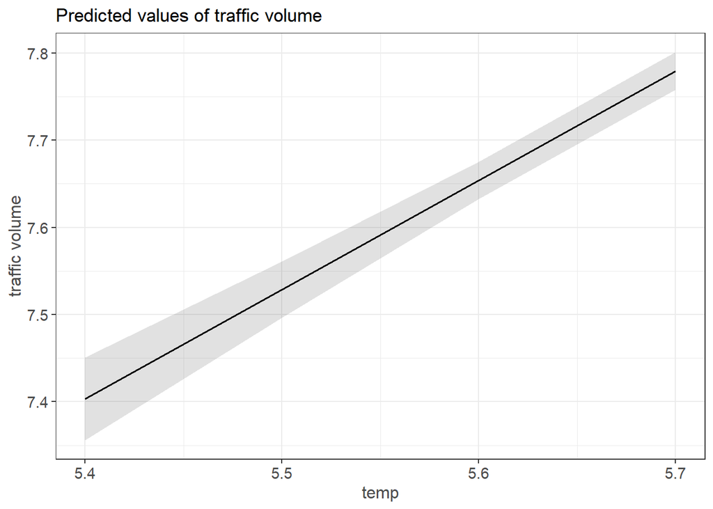

```r
set_theme(base = theme_bw())

# Temperature vs. traffic volume
plot_model(train_best_model, type = "pred", terms = c("temp"), colors = "blue")
```

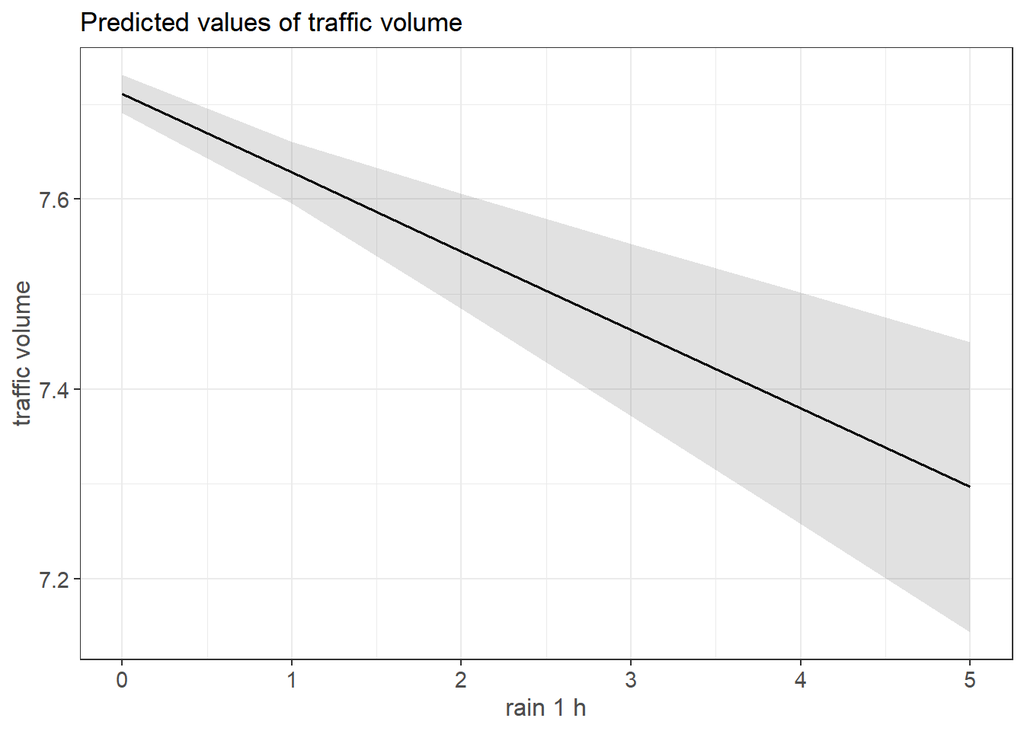

```r
# Raining (1 hour) vs. traffic volume
plot_model(train_best_model, type = "pred", terms = c("rain_1h"))
```

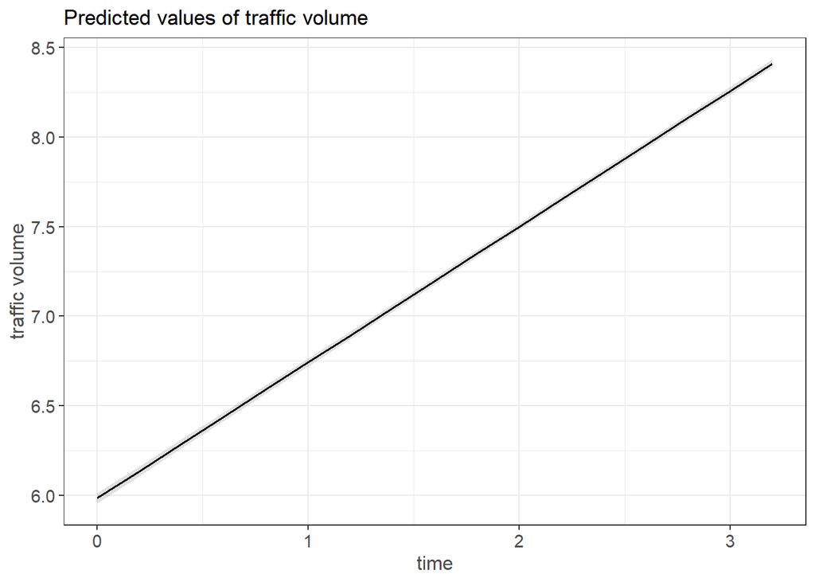

```r
# Daytime vs. traffic volume
plot_model(train_best_model, type = "pred", terms = c("time"))
```

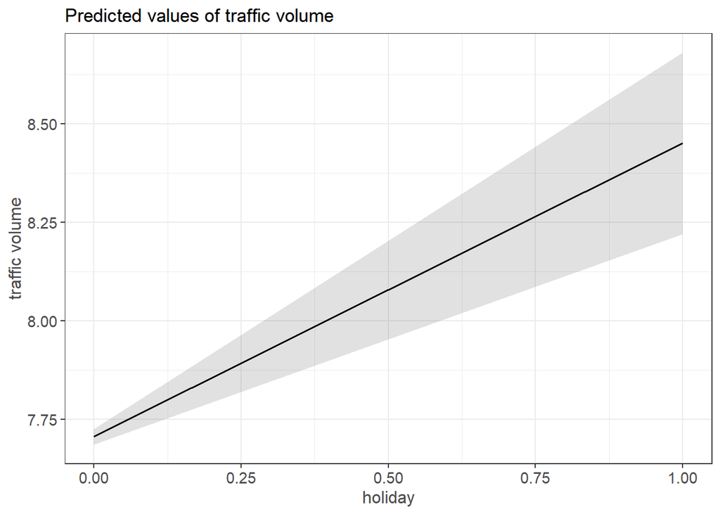

```r
# Holiday vs. traffic volume
plot_model(train_best_model, type = "pred", terms = c("holiday"))
```

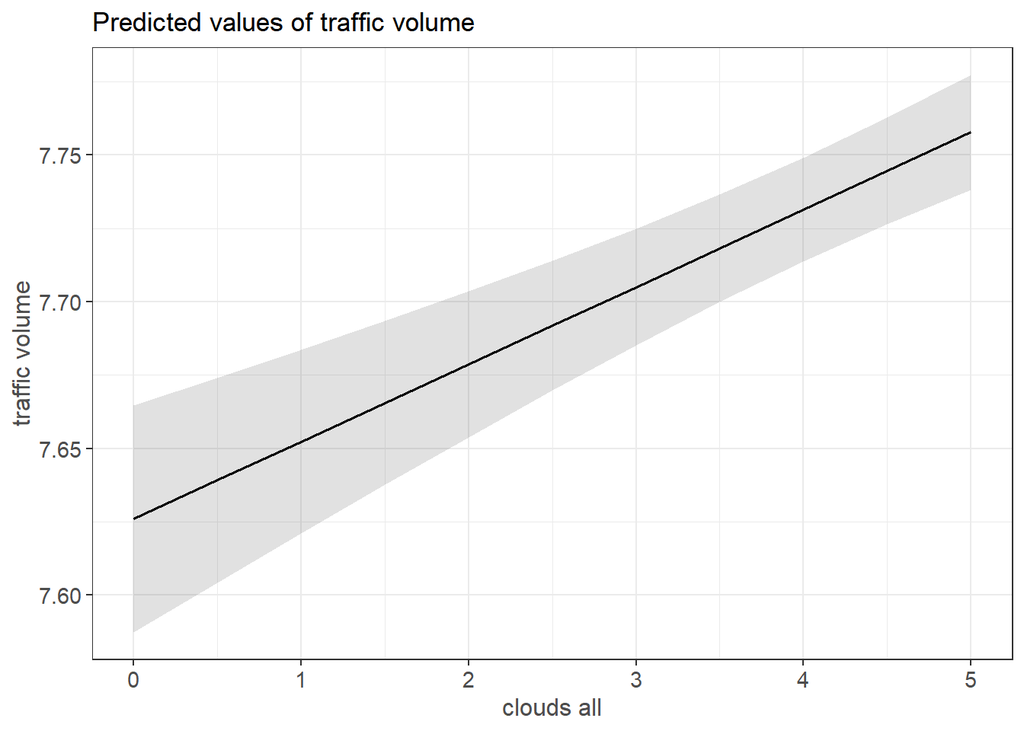

```r
# Clouds (%) vs. traffic volume
plot_model(train_best_model, type = "pred", terms = c("clouds_all"))
```

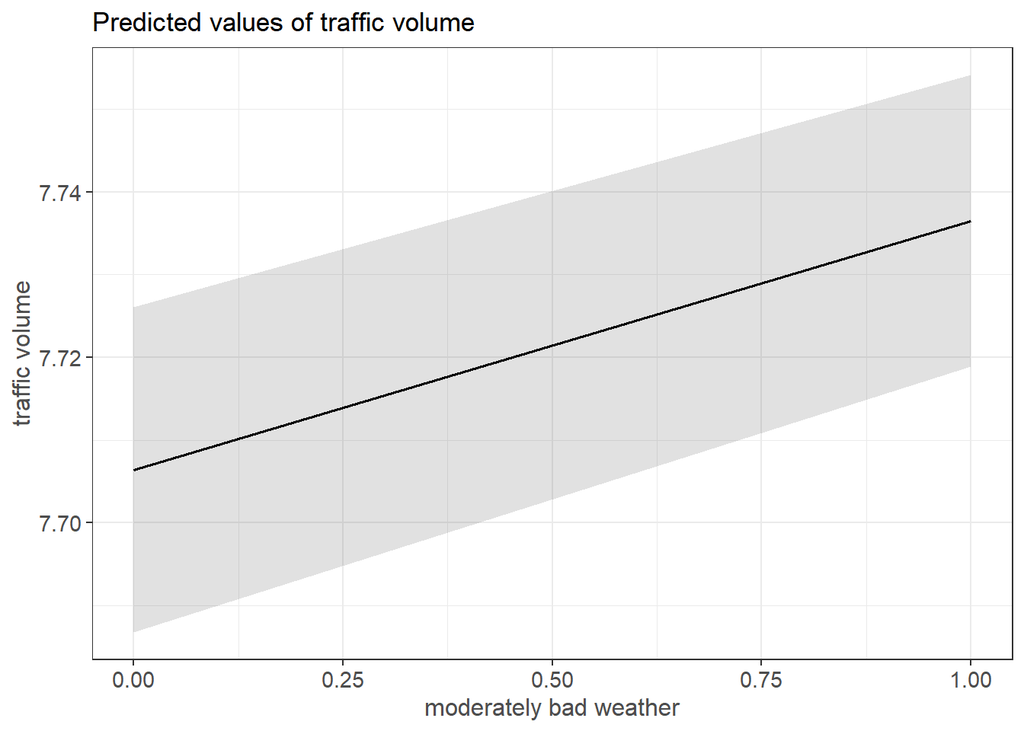

```r
# moderately_bad_weather vs. traffic volume
plot_model(train_best_model, type = "pred", terms = c("moderately_bad_weather"))
```

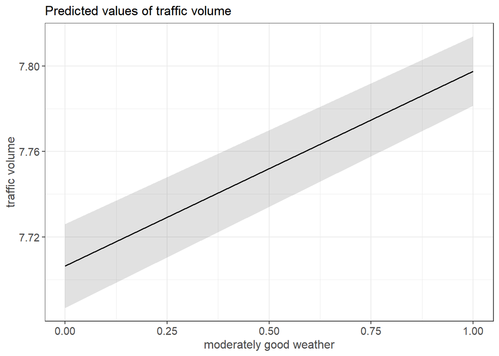

```r
# moderately_good_weather vs. traffic volume
plot_model(train_best_model, type = "pred", terms = c("moderately_good_weather"))
```

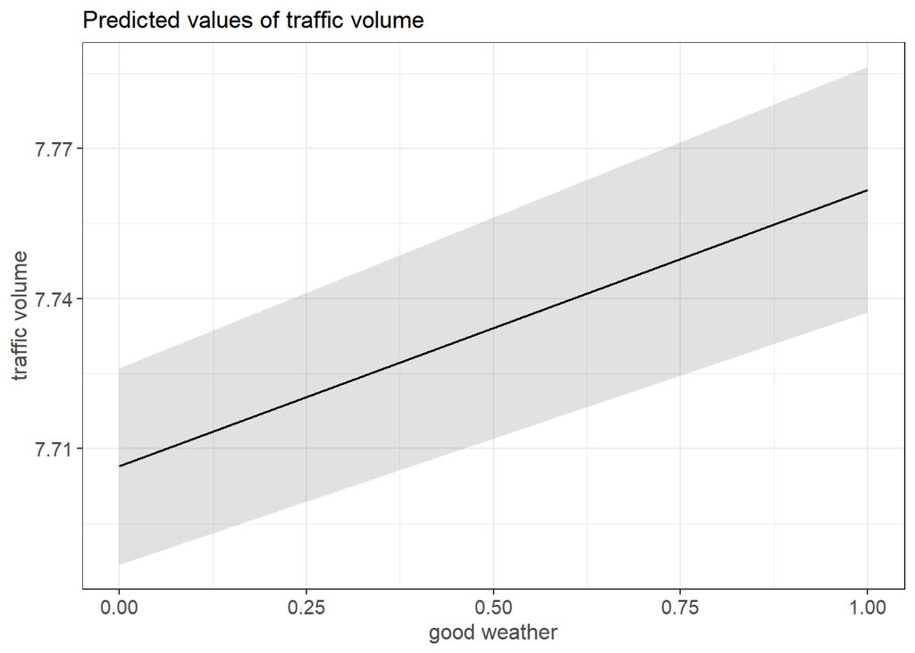

```r
# good_weather vs. traffic volume
plot_model(train_best_model, type = "pred", terms = c("good_weather"))
```

```r
names(df_split_train1)
```

```
## [1] "traffic_volume"          "temp"
## [3] "rain_1h"                 "clouds_all"
## [5] "time"                    "holiday"
## [7] "moderately_bad_weather"  "moderately_good_weather"
## [9] "good_weather"
```